# Rapport

Arthur Junod

# Intro

L’analyse des données, que nous allons utiliser durant ce travail pratique, permet de faire ressortir ou voir certaines caractéristiques en observant les données que nous avons. Nous allons les mettre en forme avec différent types de graphiques et également utiliser certaines fonctions que *R* nous mets à disposition afin de mieux comprendre ces données.

# Ex1

### b)

*Charger les données dans R en utilisant les fonctions `scan()` et `read.table()`.*

```r
cpus <- scan("../datas/cpus.txt")
examen <- read.table("../datas/examen.txt", header = TRUE)
```

### c)

*Pour voir le contenu de l’objet `cpus`, taper l’instruction*

```r
cpus
```

```
 [1]  46 110  38  22  11 510  38  76  21  92  44  66  24  10  25 915  26  56  40
[20]   7 185 141  14  24  19  24  32  33 370  58  12  66  62  12  45 133  64 144
[39]  36 130  16  36  65 136  60  18  66  30 100  36
```

```r
examen
```

```
   groupe note
1       A  3.5
2       A  3.0
3       A  2.0
4       A  3.8
5       A  2.0
6       A  1.9
7       A  4.4
8       A  3.5
9       A  4.3
10      A  4.0
11      A  3.8
12      A  3.9
13      A  2.2
14      A  3.4
```

[output cut: 18 more lines]

### d)

*Pour accéder à la 12ème composante du vecteur `cpus`, utiliser la commande*

```r
cpus[12]
```

```
[1] 66
```

### e)

*Pour obtenir une partie du vecteur `cpus` comme par exemple les éléments du vecteur compris entre la 3ème et la 19ème composante, taper l’instruction*

```r
cpus[3:19]
```

```
 [1]  38  22  11 510  38  76  21  92  44  66  24  10  25 915  26  56  40
```

### f)

*Pour extraire du vecteur `cpus` ses éléments supérieurs à* $190$, utiliser la commande

```r
cpus[cpus>190]
```

```
[1] 510 915 370
```

### g)

*Il est possible d’accéder directement aux composantes d’une table par le nom. Par exemple, si on veut afficher la composante `note` de l’objet `examen`, on peut utiliser la commande*

```r
examen$note
```

```
 [1] 3.5 3.0 2.0 3.8 2.0 1.9 4.4 3.5 4.3 4.0 3.8 3.9 2.2 3.4 4.2 3.3 4.0 4.5 4.3
[20] 5.6 5.9 3.9 4.0 4.5 5.4 4.4 4.7 4.6 3.8 4.3 3.8 3.2
```

### h)

*On peut aussi accéder en profondeur aux composantes comme par exemple par la commande*

```r
examen$note[7]
```

```
[1] 4.4
```

### i)

*La méthode la plus simple pour créer un vecteur consiste à énumérer ses éléments à l’aide de la fonction `c()` :*

```r
mesdonnees<-c(2.9, 3.4, 3.4, 3.7, 3.7, 2.8, 2.1, 2.5, 2.6)
mesdonnees
```

```
[1] 2.9 3.4 3.4 3.7 3.7 2.8 2.1 2.5 2.6
```

```r
couleurs<-c("bleu", "vert", "blanc", "noir", "jaune")
couleurs
```

```
[1] "bleu"  "vert"  "blanc" "noir"  "jaune"
```

### j)

*On peut ôter des composantes d’un vecteur en indiquant entre crochets les indices précédés du signe négatif comme par exemple*

```r
mesdonnees[-c(3:5)]
```

```
[1] 2.9 3.4 2.8 2.1 2.5 2.6
```

### k)

*Finalement, le contenu de votre environnement de travail est affiché à l’aide de la fonction `ls().`*

```r
ls()
```

```
[1] "couleurs"   "cpus"       "examen"     "mesdonnees"
```

# Ex2

### a)

*Construire un diagramme branche-et-feuilles, un histogramme et une boîte à moustaches des données observées à l’aide des commandes ci-dessous.*

```r
stem(cpus)
```

```
  The decimal point is 2 digit(s) to the right of the |

  0 | 111111222222223333344444445566666777789
  1 | 01334449
  2 |
  3 | 7
  4 |
  5 | 1
  6 |
  7 |
  8 |
  9 | 2
```

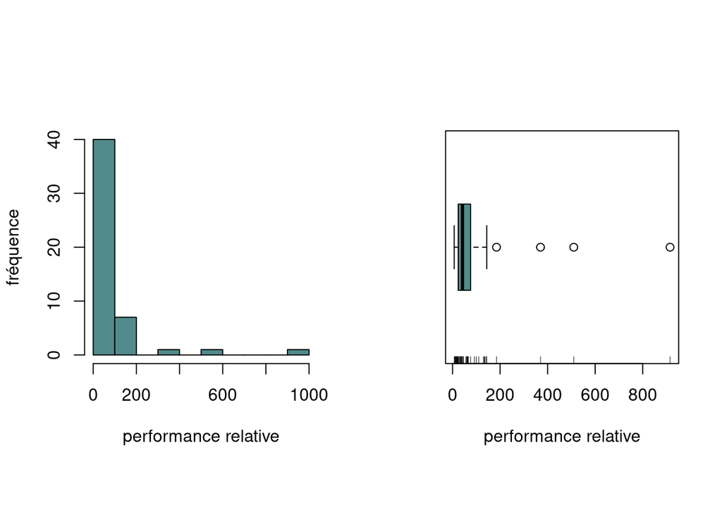

```r
par(mfrow=c(1,2), pty="s")
hist(cpus, xlab="performance relative", ylab="fréquence", main="",
     col="darkslategray4")
boxplot(cpus, xlab="performance relative", col="darkslategray4", horizontal=T)
rug(cpus)
```

```r
par(mfrow=c(1,1))
```

1. *Quels sont les effets de cette commande ?*

La fonction `par(mfrow=c(1,2)`, `pty="s")` permet de de séparer la zone graphique en plusieurs partie afin de permettre à plusieur graphique de se la partager. `mfrow` donne le format que les lignes aurons ici on donne `c(1,2)` comme valeur à ce paramètre on va donc disposer les graphiques en 1 ligne et 2 colonnes. `pty` permet de lui donner la valeur `"s"` qui indique que l’on veut donner des zones de dessin carrée.

2. *Quel est l’effet de la fonction `rug()` ?*

La fonction `rug(cpus)` rajoute les traits sur l’axe des données dans le graphique de la boite à moustache.

### b)

*Commenter la distribution des valeurs observées en se basant sur les graphiques de la @fig-hist-boxplot-cpus : valeur(s) atypique(s), asymétrie.*

### c)

*Calculer la performance relative médiane et la performance relative moyenne des valeurs observées en utilisant les fonctions de R adéquates.*

```r
meanCpus <- mean(cpus)
medianCpus <- median(cpus)

meanCpus
```

```
[1] 86.88
```

```r
medianCpus
```

```
[1] 42
```

*Est-il plus approprié d’utiliser la médiane ou la moyenne ?*

On peut voir que la moyenne equivaut à plus du double de la médiane. Cela peut s’expliquer par le fait que la moyenne est beaucoup plus influencée par les valeurs atypiques et donc il serait plus convenable dans ce cas d’utiliser la médiane.

### d)

*Déterminer le(s) mode(s) des valeurs observées à l’aide des commandes suivantes :*

```r
n.cpus<-table(cpus)
as.numeric(names(n.cpus)[n.cpus==max(n.cpus)])
```

```
[1] 24 36 66
```

Les modes sont ceux affichés par la commande.

### e)

*Que fait la commande suivante ?*

```r
summary(cpus)
```

```
   Min. 1st Qu.  Median    Mean 3rd Qu.    Max.
   7.00   24.00   42.00   86.88   73.50  915.00
```

Cette commande permet d’avoir un résumé d’une table en affichant son/sa:

- Minimum
- 1er quartile
- Mediane
- Moyenne
- 3ème quartile
- Maximum

Cela nous permet, en une commande, d’avoir un assez bon apercu d’une table entière.

### f)

*En effectuant aucun calcul, décrire l’effet sur la moyenne et sur la médiane des trois interventions suivantes :*

1. *ajouter un processeur de performance relative* $43$;

2. *soustraire* $9$ à chaque valeur observée;

3. *diviser chaque observation par* $3$.

La division impactera autant la moyenne que la médiane (elle seront divisé les deux par 3).

### g)

*Calculer l’écart-type des performances relatives une fois avec les valeurs atypiques et une fois sans en utilisant la fonction `sd()`. Les valeurs atypiques peuvent être déterminées à l’aide de la fonction `boxplot()` avec `plot=FALSE` comme argument.*

```r
boxplot(cpus, xlab="performance relative", col="darkslategray4", horizontal=T, plot=F)
```

```
$stats
     [,1]
[1,]    7
[2,]   24
[3,]   42
[4,]   76
[5,]  144

$n
[1] 50

$conf
         [,1]
[1,] 30.38082
[2,] 53.61918

$out
[1] 510 915 185 370

$group
[1] 1 1 1 1

$names
[1] ""
```

```r
cpus_wout <- cpus[!cpus %in% c(510, 915, 185, 370)]
setdiff(cpus, cpus_wout)
```

```
[1] 510 915 185 370
```

```r
sd(cpus)
```

```
[1] 148.4294
```

```r
sd(cpus_wout)
```

```
[1] 38.5864
```

*Que constate-t-on ? L’écart-type est-il un indicateur robuste ?*

On peut trouver les valeurs extrêmes avec la partie **$out** du `boxplot(plot = F)` (donc ici 510, 915, 185 et 370). On crée donc un nouveau vecteur **cpus_wout** qui sera un nouveau vector sans les valeurs extrêmes. On peut d’ailleurs vérifier que la création se soit bien faite avec la fonction `setdiff()`qui retourne la différence entre 2 vecteurs. On voit ensuite avec `sd()`que l’écart-type est très influencé par ces valeurs car il passe de 148.4294 à 38.5864 une fois retirées. Il n’est donc pas robuste.

# Ex3

```r
library(tidyverse)
```

### a)

*Tracer les boîtes à moustaches en parallèle en utilisant les commandes suivantes :*

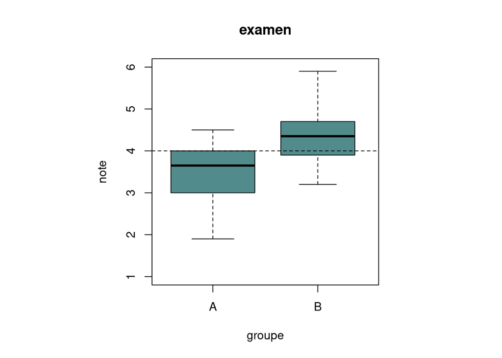

```r
lblue<-"#528B8B"
par(pty="s")
boxplot(note~groupe, data=examen, ylim=c(1,6), xlab="groupe",
        varwidth=T, col=lblue, main="examen")
abline(h=4, lty=2)
```

### b)

*Rajouter les bâtonnets des notes des étudiants des deux classes, sur le côté gauche des boîtes à moustaches pour la classe* $A$ (`side=2` comme argument de la fonction `rug()`) et sur le côté droite pour la classe $B$ (`side=4` comme argument de la fonction `rug()`).

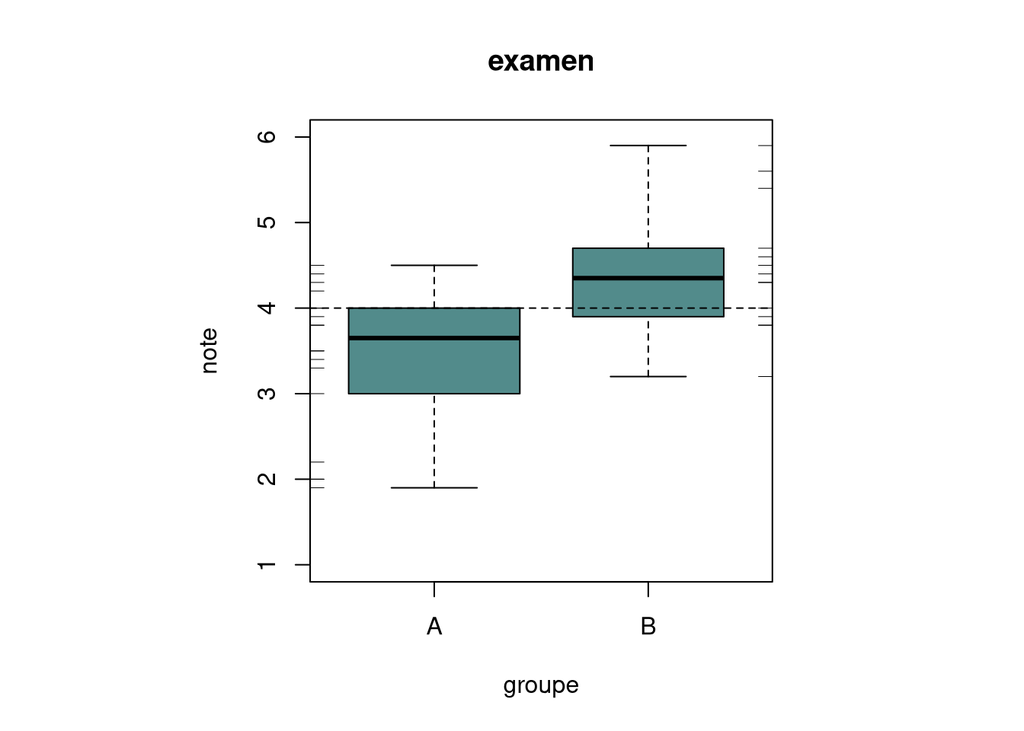

```r
lblue<-"#528B8B"
par(pty="s")
note.A<-split(examen$note, examen$groupe)$A
note.B<-split(examen$note, examen$groupe)$B
boxplot(note~groupe, data=examen, ylim=c(1,6), xlab="groupe",
        varwidth=T, col=lblue, main="examen")
rug(note.A, side=2)
rug(note.B, side=4)
abline(h=4, lty=2)
```

### c)

*En se basant sur la @fig-boites-moustaches-parallele, existe-t-il une différence significative entre les deux groupes à l’examen de fin d’unité ?*

La majorité des notes du groupe B sont supérieur à celle du groupe A. On le remarque car la boite du groupe B se situe au dessus du groupe A.

### d)

*Observe-t-on sur les boîtes à moustaches une différence entre les dispersions des deux groupes ?*

Non les deux groupes ont une dispersion similaire car leurs moustaches et la boite sont de taille proche.

### e)

*Calculer les écarts-types des deux groupes à l’aide des fonctions `by()` et `sd()`.*

```r
by(examen$note, list(examen$groupe), sd)
```

```
: A
[1] 0.8655536
------------------------------------------------------------
: B
[1] 0.7531618
```

*En se basant sur les écarts-types, existe-t-il une différence en dispersion entre les deux groupes à l’examen de fin d’unité ?*

### f)

*Que peut-on déduire en comparant les conclusions établies en c), d) et e) ?*

On peut donc en déduire que la seule différence entre les deux groupes est que le groupe B a de meilleurs notes que le groupe A mais qu’en regardant l’ecart-type on peut en déduire que l’examen devait être équitable.

### g)

*Un autre graphique pour étudier les éventuelles différences entre les deux groupes à l’examen de fin d’unité se trouve dans la @fig-densite.*

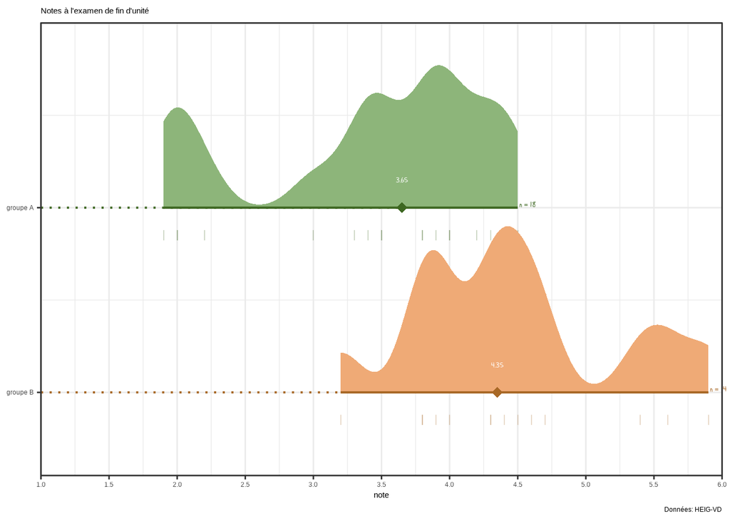

Diagramme de densité en parallèle.

*À votre avis, entre les boîtes à moustaches en parallèle et le graphique tracé ci-dessus, lequel est le plus approprié ?*

Les boîtes à moustaches permettent de mieux voir l’écart type et fais ressortir mieux les valeurs représentatives des deux groupes. Je pense donc que la boîte à moustache serait plus représentative.

# Ex4

### a)

```r
library(ggplot2)
library(arules)

data("AdultUCI")
dframe<-AdultUCI[, c("education", "hours-per-week")]
colnames(dframe)<-c("education", "hours_per_week")
str(dframe)
```

```
'data.frame':   48842 obs. of  2 variables:
 $ education     : Ord.factor w/ 16 levels "Preschool"<"1st-4th"<..: 14 14 9 7 14 15 5 9 15 14 ...
 $ hours_per_week: int  40 13 40 40 40 40 16 45 50 40 ...
```

1. *Pourquoi ce changement de nom de variable ?*

On remet les valeurs de **AdultUCI** dans **dframe** pour ne récupérer que 2 colonnes qui nous intéresent.

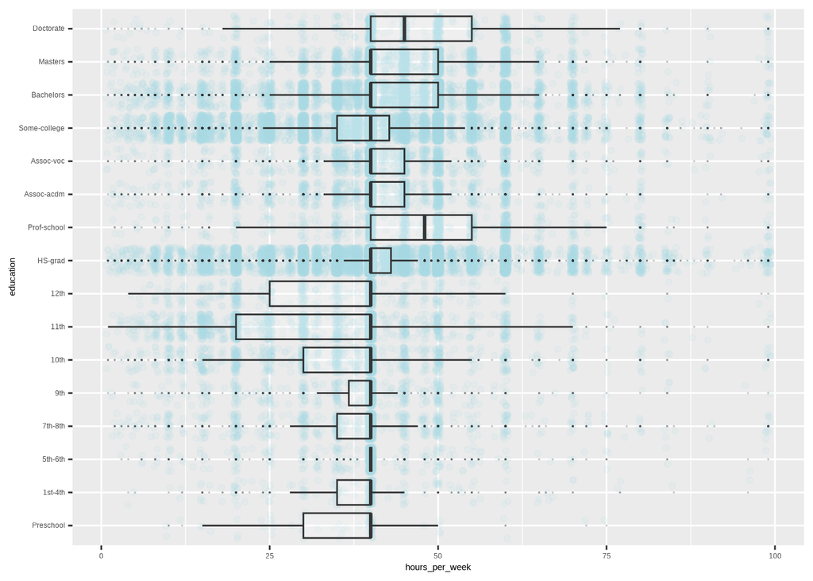

```r
ggplot(dframe, aes(x=hours_per_week, y=education)) +
  geom_point(colour="lightblue", alpha=0.1, position="jitter") +
  geom_boxplot(outlier.size=0, alpha=0.2)
```

*Commenter le graphique obtenu.*

On voit qu’il y a une sorte de tendance à l’augmentation du nombres d’heures par semaine plus le niveau d’éducation est élevé. La médiane est pareil dans la plupart des boites.

### b)

*Calculer la proportion d’observations contenant des valeurs manquantes en utilisant les commandes ci-dessous.*

```r
dim(AdultUCI)
```

```
[1] 48842    15
```

```r
nrows<-nrow(AdultUCI)
n.missing<-rowSums(is.na(AdultUCI))
sum(n.missing>0)/nrows
```

```
[1] 0.3824577
```

### c)

*En se basant sur les boîtes à moustaches en parallèle de la @fig-recensement, pour quel type de formation observe-t-on la plus grande dispersion du temps de travail ? Existe-t-il une différence entre les médianes des types de formation ? En donner brièvement la raison.*

### d)

*Pour chaque type de formation, on peut déterminer puis afficher à l’écran le temps maximal de travail hebdomadaire à l’aide des commandes*

```r
nx<-by(dframe$hours_per_week, dframe$education, max, na.rm=T)
nx
```

```
dframe$education: Preschool
[1] 75
------------------------------------------------------------
dframe$education: 1st-4th
[1] 96
------------------------------------------------------------
dframe$education: 5th-6th
[1] 99
------------------------------------------------------------
dframe$education: 7th-8th
[1] 99
------------------------------------------------------------
dframe$education: 9th
[1] 99
------------------------------------------------------------
dframe$education: 10th
[1] 99
------------------------------------------------------------
dframe$education: 11th
[1] 99
------------------------------------------------------------
dframe$education: 12th
[1] 99
------------------------------------------------------------
dframe$education: HS-grad
[1] 99
------------------------------------------------------------
dframe$education: Prof-school
[1] 99
------------------------------------------------------------
dframe$education: Assoc-acdm
[1] 99
------------------------------------------------------------
dframe$education: Assoc-voc
[1] 99
------------------------------------------------------------
dframe$education: Some-college
[1] 99
------------------------------------------------------------
dframe$education: Bachelors
[1] 99
------------------------------------------------------------
dframe$education: Masters
[1] 99
------------------------------------------------------------
dframe$education: Doctorate
[1] 99
```

*La formation pour laquelle un temps maximal a été observé se détermine par les commandes*

```r
max(nx)
```

```
[1] 99
```

```r
names(nx)[nx==max(nx)]
```

```
 [1] "5th-6th"      "7th-8th"      "9th"          "10th"         "11th"
 [6] "12th"         "HS-grad"      "Prof-school"  "Assoc-acdm"   "Assoc-voc"
[11] "Some-college" "Bachelors"    "Masters"      "Doctorate"
```

*Est-ce surprenant ?*

Oui mais en y réfléchissant on pourrait se demander si ces valeurs sont vraiment pertinentes étant donné que presque tous les niveaux d’éducation ont atteint 99h et si il n’y aurait pas des valeurs érronées.

### e)

*En s’inspirant des commandes utilisées ci-dessus, déterminer la formation pour laquelle la distribution des temps de travail se caractérise par le plus petit écart-type.*

```r
nsd<-by(dframe$hours_per_week, dframe$education, sd, na.rm=T)
names(nsd)[nsd==min(nsd)]
```

```
[1] "Assoc-voc"
```

### f)

*Observe-t-on un résultat similaire en utilisant l’étendue interquartiles à l’aide de la fonction `IQR()`?*

```r
niqr<-by(dframe$hours_per_week, dframe$education, IQR, na.rm=T)
names(niqr)[niqr==min(niqr)]
```

```
[1] "5th-6th"
```

Non nous trouvons **5th-6th**.

# Ex5

# Ex6

### a)

*Tracer le nuage de points de la largeur (`Petal.Width`) versus la longueur (`Petal.Length`) des pétales des iris en utilisant les librairies `ggplot2` et `ggforce`.*

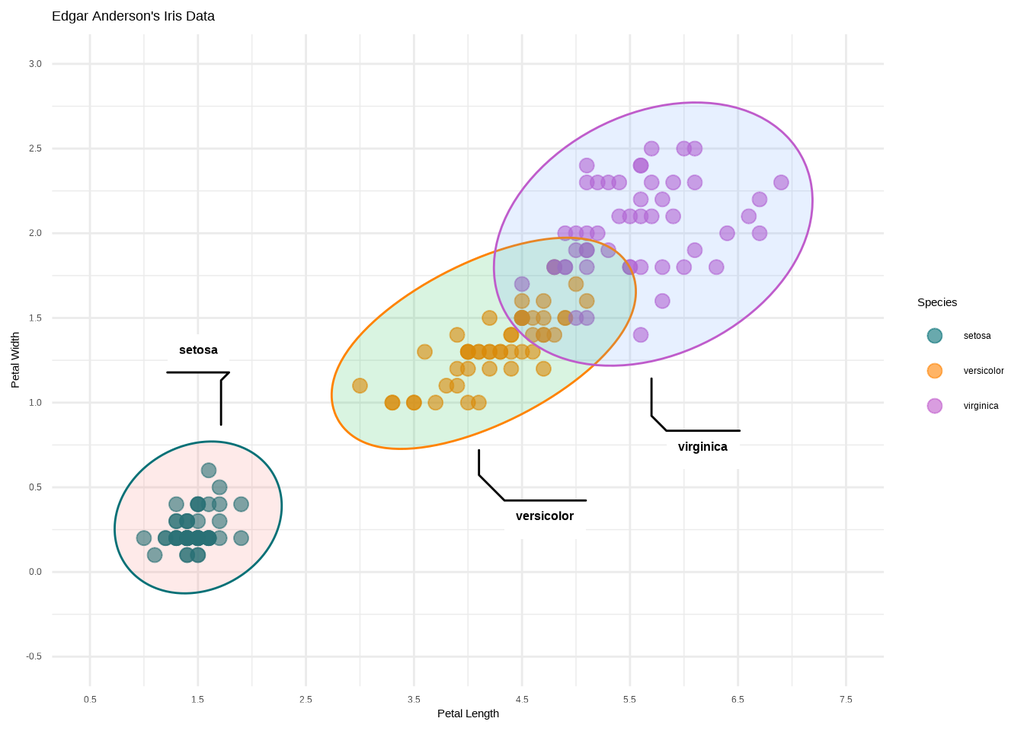

```r
pCol <- c('#057076', '#ff8301', '#bf5ccb')

plot.iris<-ggplot(iris, aes(x=Petal.Length, y=Petal.Width, col=Species)) +
scale_color_manual(values=pCol) +
scale_x_continuous(breaks=seq(0.5, 7.5, by=1), limits=c(0.5, 7.5)) +
scale_y_continuous(breaks=seq(-0.5, 3, by=0.5), limits=c(-0.5, 3)) +
labs(title="Edgar Anderson's Iris Data",
x="Petal Length",
y="Petal Width") +
theme(plot.title=element_text(size=12, hjust=.5),
axis.title=element_text(size=10, vjust=-2),
axis.text=element_text(size=10, vjust=-2)) +
geom_point(aes(color=Species), alpha=.6, size=3) +
theme_minimal()

plot.iris +
ggforce::geom_mark_ellipse(
    aes(fill=Species, label=Species),
    alpha=.15, show.legend=FALSE
)
```

### b)

*En se basant sur le graphique de nuage de points, existe-t-il une relation entre la largeur et la longueur des pétales des iris ? Dans l’affirmative, de quelle nature est-elle ?*

Oui on peut voir une relation linéaire positive.

### c)

*Remarque-t-on des observations inhabituelles dans le graphique de nuage de points ?*

Non. Il y a plus de répartition pour **virginica** mais toutes les valeurs suivent la même tendance (linéaire).

### d)

*Déterminer la corrélation entre la largeur et la longueur des pétales des iris en utilisant la fonction `cor()`.*

```r
cor(iris$Petal.Length, iris$Petal.Width)
```

```
[1] 0.9628654
```

### e)

*Quelle valeur attribueriez-vous à la longueur des pétales des iris pour distinguer les iris Setosa des deux autres espèces ?*

On peut assez facilement utiliser la valeur 2.5 pour dire que tout iris avec une longueur de pétales plus petite que 2.5 est de l’espèce **setosa**.

### f)

*Des animations peuvent être créées dans R en utilisant la librairie `gganimate`. Un exemple peut être conçu en utilisant le code ci-dessous.*

```r
library(gganimate)

anim<-plot.iris+
  transition_states(Species,
                    transition_length = 2,
                    state_length = 1)

anim
```

[output not shown]

```r
anim +
  enter_fade() +
  exit_shrink() +
  ggtitle('Now showing {closest_state}',
        subtitle = 'Frame {frame} of {nframes}')
```

[output not shown]

# Conclusion

Durant le Tp nous avons appris les bases de R. Donc comment manipuler des objets dans un projet R avec `mean(), max(), min(), ...`. Et aussi des fonctions plus générales comme `by(), cor(), rug()`. Il nous a permit également de nous familiariser avec quelques concepts comme l’écart-type ou le coefficient de corrélation et de nous habituer a analyser “a la volée” un graphique juste en le regardant.